# Lab 13

In this lab we’ll run through differential expression analysis using Salmon and DESeq2. Instructions are provided for running Salmon and importing the results to Bioconductor, then you can pick up with the Lecture 13 Notes for how to run DESeq2.

## Building the Salmon index

Launch the Ubuntu virtual machine. Move into your shared directory with the files.

```
cd /media/sf_ricedata/
```

Now we’ll build an alignment index for Salmon.

```
salmon index -t Osativa_323_v7.0.transcript.fa.gz -i rice_index
```

This will create a folder called `rice_index` containing files that Salmon will use to quickly identify which read belongs to which transcript.

## Quantifying reads belonging to transcripts

Since we have nine files to process, it will be easiest to loop through them.

Run

```
nano quant.sh
```

to open a text editor for a script. Fill in the script as:

```bash
#!/bin/bash

for n in 49 50 51 52 53 54 55 56 57
do
echo $n
salmon quant -i rice_index -l A -r DRR0003${n}.fastq -o DRR0003${n}_quant
done
```

Depending on time, you can try adding the `--gcBias` flag to your `salmon quant` command to improve quantification quality. The Salmon results that I put on Compass were made using the above script, without the `--gcBias` flag, although it is generally a good idea to use it.

Press Ctrl-O to save, hit Enter to keep the file name, then Ctrl-X to quit.

Now run the script:

```
sh quant.sh
```

Once it is done, you should have a folder for each of the FASTQ files that you quantified.

## Importing Salmon output to DESeq2

Open up RStudio in Windows. Load the packages for today. Any that you don’t have can be installed with `BiocManager::install` or `install.packages` as appropriate.

```r
# from Bioconductor; get wtih BiocManager::install
library(tximport)
library(DESeq2)
library(GenomicFeatures)

# from CRAN; get with install.packages
library(readr)
library(ggplot2)
library(ggbeeswarm)
library(pheatmap)
```

We need to set up a table of sample information.

```r
rice_sam <- data.frame(row.names = paste("DRR0003", 49:57, sep = ""),
                       tissue = c("root", "shoot")[c(2,1,2,1,2,1,2,1,1)],
                       treatment = c("control", "salinity_stress")[c(1,1,2,2,1,1,2,2,2)],
                       run = paste("DRR0003", 49:57, sep = ""))
rice_sam
```

```
##           tissue       treatment       run
## DRR000349  shoot         control DRR000349
## DRR000350   root         control DRR000350
## DRR000351  shoot salinity_stress DRR000351
## DRR000352   root salinity_stress DRR000352
## DRR000353  shoot         control DRR000353
## DRR000354   root         control DRR000354
## DRR000355  shoot salinity_stress DRR000355
## DRR000356   root salinity_stress DRR000356
## DRR000357   root salinity_stress DRR000357
```

We will also need a list of files contining the quantification results. Make sure that whatever paths you create with `file.path` are correct with respect to your current working directory.

```r
rice_quant_files <- file.path("Salmon_output", paste(rice_sam$run, "_quant", sep = ""), "quant.sf")
names(rice_quant_files) <- rice_sam$run
rice_quant_files
```

```
##                                DRR000349
## "Salmon_output/DRR000349_quant/quant.sf"
##                                DRR000350
## "Salmon_output/DRR000350_quant/quant.sf"
##                                DRR000351
## "Salmon_output/DRR000351_quant/quant.sf"
##                                DRR000352
## "Salmon_output/DRR000352_quant/quant.sf"
##                                DRR000353
## "Salmon_output/DRR000353_quant/quant.sf"
##                                DRR000354
## "Salmon_output/DRR000354_quant/quant.sf"
##                                DRR000355
## "Salmon_output/DRR000355_quant/quant.sf"
##                                DRR000356
## "Salmon_output/DRR000356_quant/quant.sf"
##                                DRR000357
## "Salmon_output/DRR000357_quant/quant.sf"
```

For `tximport`, we need a data frame indicating how transcripts correspond to genes. We can make this from a `TxDb` object.

```r
rice_TxDb <- makeTxDbFromGFF("Osativa_323_v7.0.gene.gff3.gz", format = "gff3",
                             dataSource = "Phytozome 12", organism = "Oryza sativa")

k <- keys(rice_TxDb, keytype = "TXNAME")
tx2gene <- select(rice_TxDb, k, "GENEID", "TXNAME")
head(tx2gene)
```

```
##             TXNAME         GENEID
## 1 LOC_Os01g01010.1 LOC_Os01g01010
## 2 LOC_Os01g01010.2 LOC_Os01g01010
## 3 LOC_Os01g01019.1 LOC_Os01g01019
## 4 LOC_Os01g01030.1 LOC_Os01g01030
## 5 LOC_Os01g01040.4 LOC_Os01g01040
## 6 LOC_Os01g01040.1 LOC_Os01g01040
```

If you are having problems reading the GFF3 file (since some of the lab computers have issues with gzipped files), go into the Linux virtual machine and do:

```
cd /media/sf_ricedata
gunzip Osativa_323_v7.0.gene.gff3.gz
```

Then you can try `makeTxDbFromGFF` again, but remove the `.gz` from the end of the file name.

Now, we can import the matrix of gene expression quantities, then create a `DESeqDataSet` from them.

```r
txi <- tximport(rice_quant_files, type = "salmon", tx2gene = tx2gene)
```

```
## reading in files with read_tsv
```

```
## 1 2 3 4 5 6 7 8 9
## summarizing abundance
## summarizing counts
## summarizing length
```

```r
riceDESeq_salmon <- DESeqDataSetFromTximport(txi, colData = rice_sam,
                                             design = ~ tissue + treatment)
```

```
## using counts and average transcript lengths from tximport
```

## Processing the dataset

Go through the same workflow that we did on Tuesday to identify differentially expressed genes.

- Filter out any genes with very low read depth.
- Make a transformed version of the dataset to use for visualization.
- Check that samples are clustering in a way that makes sense.
- Run the DESeq analysis.
- Identify interesting genes using the same criteria as before.
- Make scatter plots and heat maps to look at the expression of significant genes.

For comparison, you can look at our results from Lecture 13 using TopHat:

```r
load("lecture13results.RData")
```

```r
# filter out low read depth genes
riceDESeq_salmon <- riceDESeq_salmon[rowSums(counts(riceDESeq_salmon)) > 1, ]

# normalize for visualization
riceDESeqRlog <- rlog(riceDESeq_salmon, blind = FALSE)
```

```
## using 'avgTxLength' from assays(dds), correcting for library size
```

```r
# get a heat map of samples
riceDist <- as.matrix(dist(t(assay(riceDESeqRlog))))
riceDist
```

```
##           DRR000349 DRR000350 DRR000351 DRR000352 DRR000353 DRR000354
## DRR000349    0.0000 380.21968 109.16755 389.96211   80.5923 382.93763
## DRR000350  380.2197   0.00000 383.28965 148.68753  380.8102  79.35021
## DRR000351  109.1675 383.28965   0.00000 382.36540  110.2084 385.91900
## DRR000352  389.9621 148.68753 382.36540   0.00000  391.1760 147.45446
## DRR000353   80.5923 380.81021 110.20838 391.17596    0.0000 383.88717
## DRR000354  382.9376  79.35021 385.91900 147.45446  383.8872   0.00000
## DRR000355  110.9961 383.58527  83.59499 383.71331  110.0736 387.12128
## DRR000356  391.9788 147.30672 384.24349  88.39553  392.1964 147.88809
## DRR000357  396.0866 154.81883 388.25653  85.53486  398.4923 149.95061
##           DRR000355 DRR000356 DRR000357
## DRR000349 110.99614 391.97880 396.08656
## DRR000350 383.58527 147.30672 154.81883
## DRR000351  83.59499 384.24349 388.25653
## DRR000352 383.71331  88.39553  85.53486
## DRR000353 110.07363 392.19639 398.49227
## DRR000354 387.12128 147.88809 149.95061
## DRR000355   0.00000 384.24115 390.91544
## DRR000356 384.24115   0.00000  98.54509
## DRR000357 390.91544  98.54509   0.00000
```

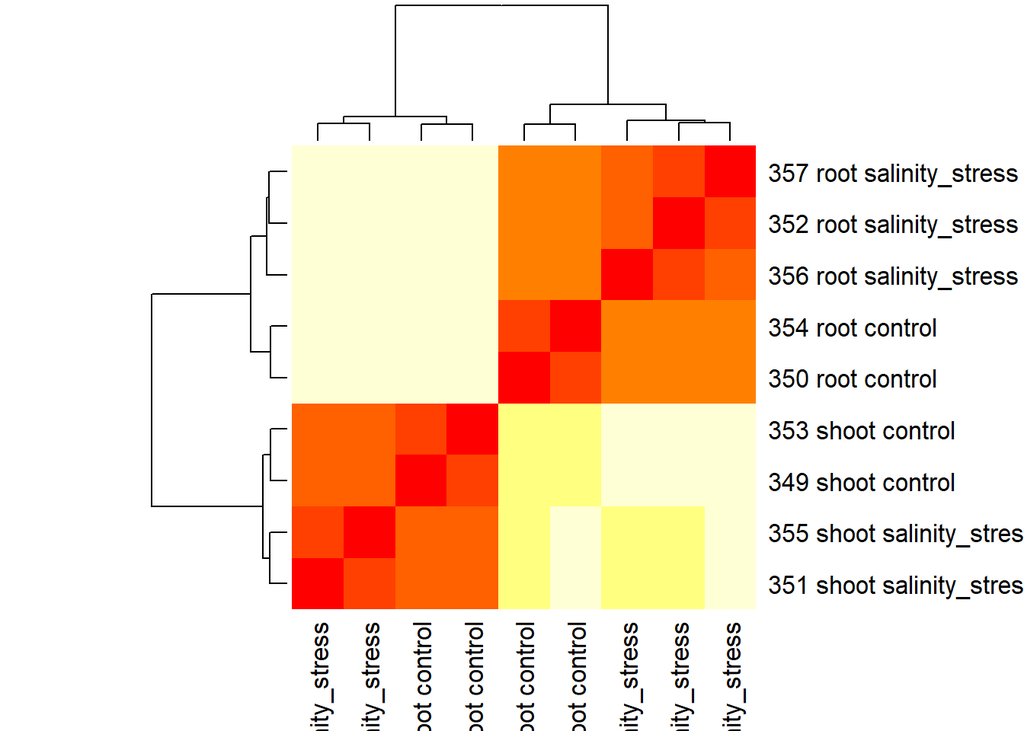

```r
newNames <- paste(349:357, rice_sam$tissue, rice_sam$treatment)
rownames(riceDist) <- newNames
colnames(riceDist) <- newNames
heatmap(riceDist)
```

```r
# run the model
riceDESeq_salmon <- DESeq(riceDESeq_salmon)
```

```
## using 'avgTxLength' from assays(dds), correcting for library size
```

```r
# look at results with LFC threshold of one
riceResults <- results(riceDESeq_salmon, lfcThreshold = 1)
summary(riceResults)
```

```
##
## out of 31586 with nonzero total read count
## adjusted p-value < 0.1
## LFC > 1.00 (up)    : 238, 0.75%
## LFC < -1.00 (down) : 30, 0.095%
## outliers [1]       : 2, 0.0063%
## low counts [2]     : 3675, 12%
## (mean count < 1)
## [1] see 'cooksCutoff' argument of ?results
## [2] see 'independentFiltering' argument of ?results
```

```r
# find interesting genes
interestingGenes_salmon <- row.names(riceResults)[which((riceResults$log2FoldChange > 1 |
                                                   riceResults$log2FoldChange < -1) &
                                                   riceResults$padj < 0.05)]
# sort them so most significant are first
interestingGenes_salmon <-
  interestingGenes_salmon[order(riceResults[interestingGenes_salmon, "padj"])]

str(interestingGenes_salmon)
```

```
##  chr [1:238] "LOC_Os03g09170" "LOC_Os09g28210" "LOC_Os01g04590" ...
```

```r
# get gene annotations
riceDefline <- read.delim("Osativa_323_v7.0.defline.txt",
                          header = FALSE, row.names = 1,
                          stringsAsFactors = FALSE)
riceDefline[interestingGenes_salmon[1:20],2]
```

```
##  [1] "ethylene-responsive transcription factor, putative, expressed"
##  [2] "bHelix-loop-helix transcription factor, putative, expressed"
##  [3] "expressed protein"
##  [4] "9-cis-epoxycarotenoid dioxygenase 1, chloroplast precursor, putative, expressed"
##  [5] "expressed protein"
##  [6] "expressed protein"
##  [7] "homeobox associated leucine zipper, putative, expressed"
##  [8] "pectinesterase, putative, expressed"
##  [9] "expressed protein"
## [10] "WRKY108, expressed"
## [11] "DUF581 domain containing protein, expressed"
## [12] NA
## [13] "helix-loop-helix DNA-binding domain containing protein, expressed"
## [14] "phytosulfokines precursor, putative, expressed"
## [15] NA
## [16] "MYB family transcription factor, putative, expressed"
## [17] "STE_MEKK_ste11_MAP3K.7 - STE kinases include homologs to sterile 7, sterile 11 and sterile 20 from yeast, expressed"
## [18] "EF hand family protein, putative, expressed"
## [19] "AP2 domain containing protein, expressed"
## [20] "enzyme of the cupin superfamily protein, putative, expressed"
```

## Questions to answer

- How did Salmon compare to TopHat in terms of the number of significant genes found? What does this tell you about the sensistivity of the two methods?

```r
# 238 significant genes were found using Salmon, compared to 223 using TopHat.
# TopHat is mostly adequate, but Salmon is slightly more sensitive.
```

- Identify a gene that was significant using one method but not the other. Compare `plotCounts` for that gene using the output from TopHat (`riceDESeq`) versus Salmon (`riceDESeq_salmon`). How is it different, and why do you think the gene was significant with one method but not the other?

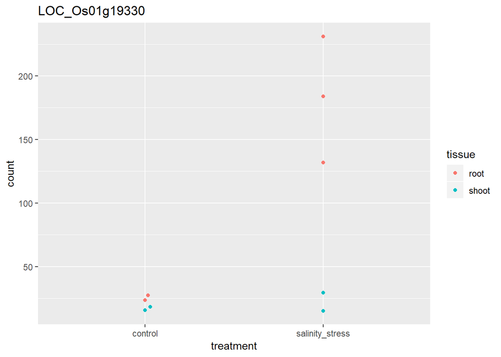

```r
# find all that were only significant with Salmon
salmon_only <-
  interestingGenes_salmon[!interestingGenes_salmon %in% interestingGenes]

lookat <- salmon_only[1]

plot1 <- plotCounts(riceDESeq, lookat, intgroup = c("treatment", "tissue"),
                    returnData = TRUE)

ggplot(plot1, aes(x = treatment, y = count, col = tissue)) +
  geom_beeswarm(cex = 2) +
  ggtitle(lookat)
```

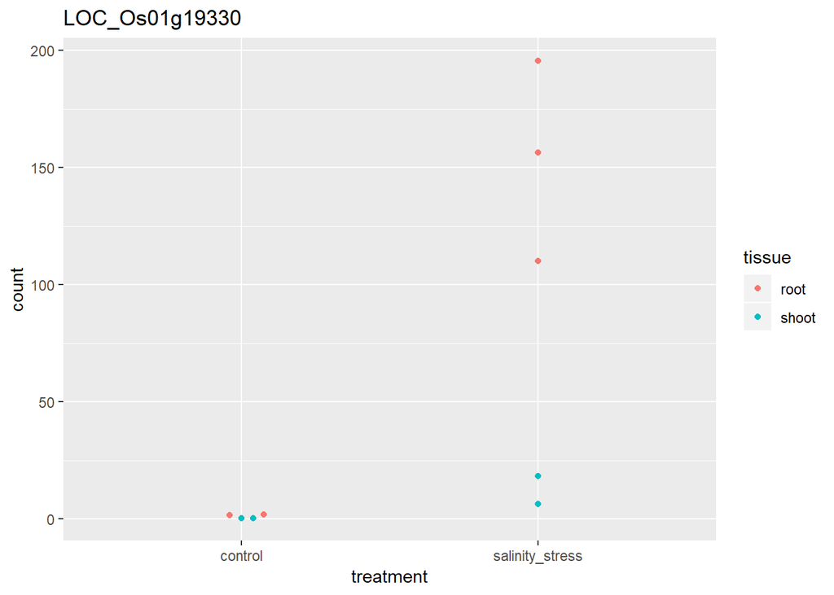

```r
plot2 <- plotCounts(riceDESeq_salmon, lookat, intgroup = c("treatment", "tissue"),
                    returnData = TRUE)

ggplot(plot2, aes(x = treatment, y = count, col = tissue)) +
  geom_beeswarm(cex = 2) +
  ggtitle(lookat)
```

```r
## For gene LOC_Os01g19330, the expression levels for the control were ~25 with
## TopHat, but ~0 with Salmon.  Expression in shoots under salinity stress was
## higher than the control with Salmon only.
## (You may pick another gene and give your explanation.)

riceDefline[lookat,2] # transcription factor
```

```
## [1] "MYB family transcription factor, putative, expressed"
```

- Make gene expression heatmaps for the twenty most significant genes, for all significant genes, and for a random set of genes. How do the samples cluster differently depending on what genes are included?

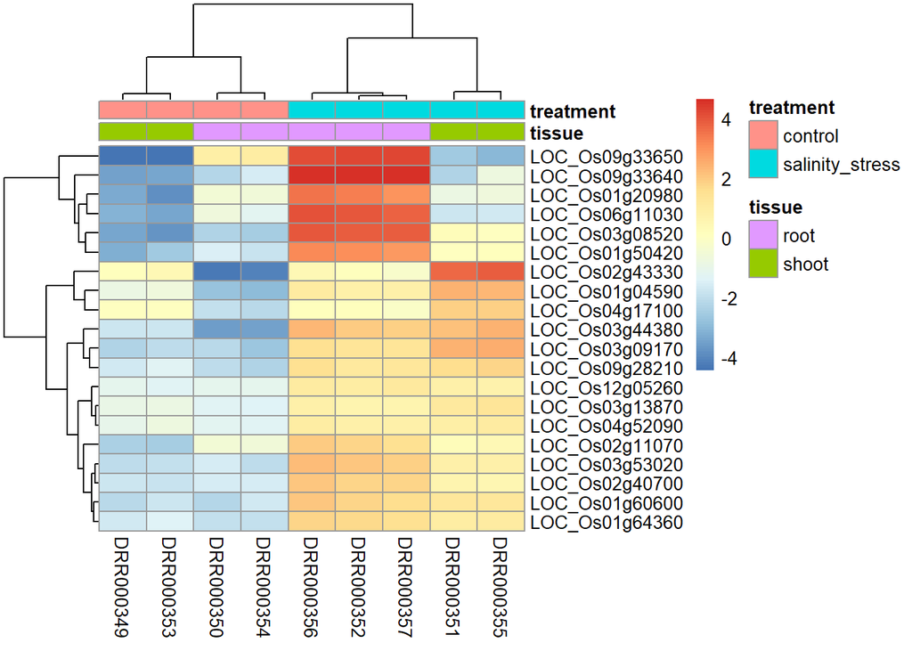

```r
# With the top 20 hits, samples are grouped by treatment, then tissue
to_plot_20 <- assay(riceDESeqRlog[interestingGenes_salmon[1:20], ])

to_plot_20 <- to_plot_20 - rowMeans(to_plot_20) # center each gene

pheatmap(to_plot_20, annotation_col = rice_sam[,c("tissue", "treatment")])
```

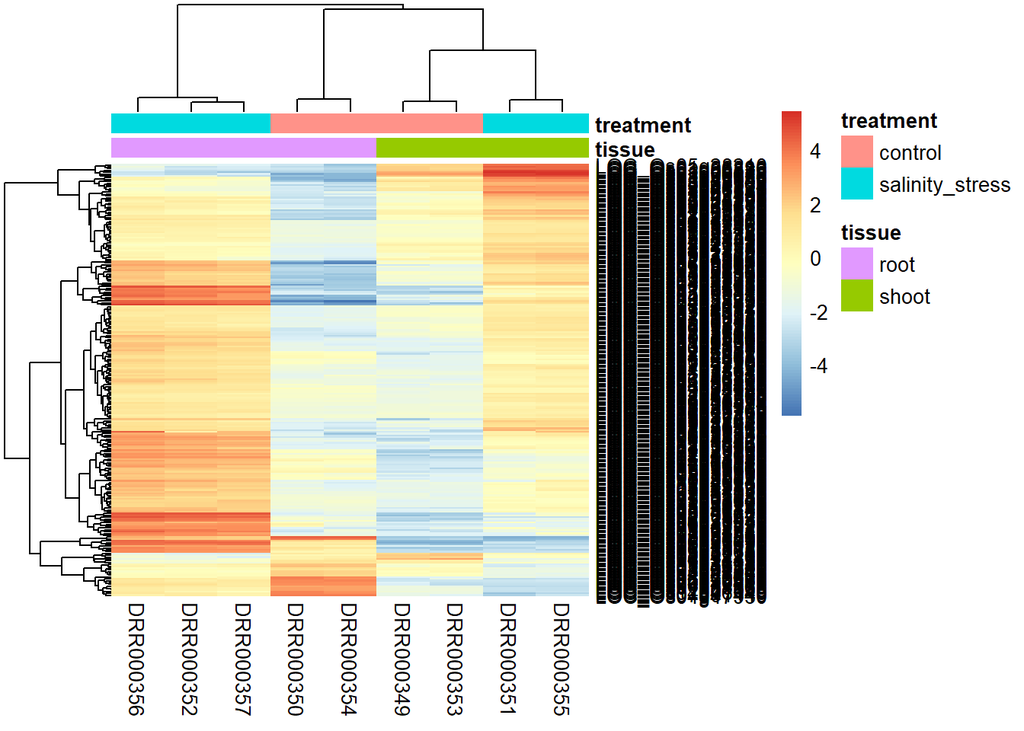

```r
# With all significant genes, the shoot samples are grouped together,
# then the root control with them.  The treated roots are grouped
# separately from everything else.
to_plot_all <- assay(riceDESeqRlog[interestingGenes_salmon, ])

to_plot_all <- to_plot_all - rowMeans(to_plot_all) # center each gene

pheatmap(to_plot_all, annotation_col = rice_sam[,c("tissue", "treatment")])
```

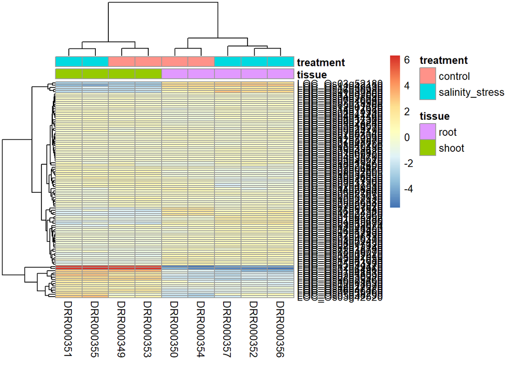

```r
# With a random set of genes, the samples are grouped first by tissue, then
# treatment.
to_plot_rand <- assay(riceDESeqRlog[sample(31586, 100), ])

to_plot_rand <- to_plot_rand - rowMeans(to_plot_rand) # center each gene

pheatmap(to_plot_rand, annotation_col = rice_sam[,c("tissue", "treatment")])
```